# Advanced Circumplex Visualization

```r
library(circumplex)
```

## Beyond the built-in plots

The `ssm_plot_circle()`, `ssm_plot_curve()`, `ssm_plot_contrast()`, and `ssm_plot_trajectory()` functions cover the most common circumplex figures, but they each produce a finished plot with a fixed set of layers. Sometimes you want more control: to overlay individual respondents on a group profile, to zoom in on a band of amplitudes, to restyle the points, or to place several circumplex panels side by side.

To make that possible, `circumplex` exposes the building blocks that the built-in plots are themselves made of. These are ordinary [`ggplot2`](https://ggplot2.tidyverse.org/) components, so you compose them with `+` and combine them freely with any other `ggplot2` layers, scales, and themes:

- `coord_circumplex()` is the **coordinate system**. It maps the `displacement` aesthetic (degrees) onto the angle and the `amplitude` aesthetic onto the radius, and it owns the amplitude-to-radius scaling for the whole plot.
- `ggcircumplex()` assembles the empty circular **canvas** — the coordinate system plus the amplitude rings, displacement spokes, and scale labels.
- `geom_ssm_point()` and `geom_ssm_arc()` are the **layers** that place profile points and their confidence regions in the circle, taking amplitude and displacement directly as aesthetics.
- `theme_circumplex()` is the **theme** the canvas is drawn with, and the rings and spokes are ordinary themed panel furniture that respond to further theming.
- `scale_x_circumplex()` is a **scale** for the angle axis of linear circumplex plots (such as the score-by-angle curve).

This vignette works through each of these and then combines them.

## The circular canvas

`ggcircumplex()` returns a `ggplot2` object containing just the circular backdrop, with no data drawn on it yet. By default it uses octant scales labeled by their angular position in degrees:

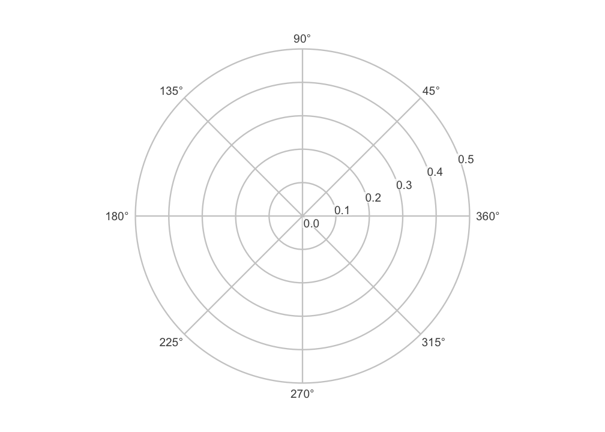

```r
ggcircumplex()
```

You can label the scales however you like. Passing a character vector labels the spokes in the order of the angles:

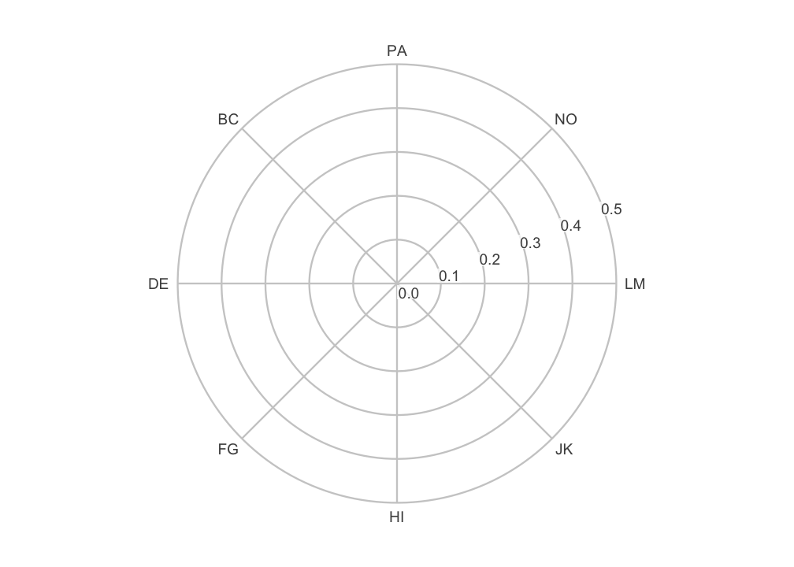

```r
ggcircumplex(octants(), labels = PANO())
```

The labels need not be abbreviations. The octant scales also have full interpersonal names, which you can put on the spokes instead:

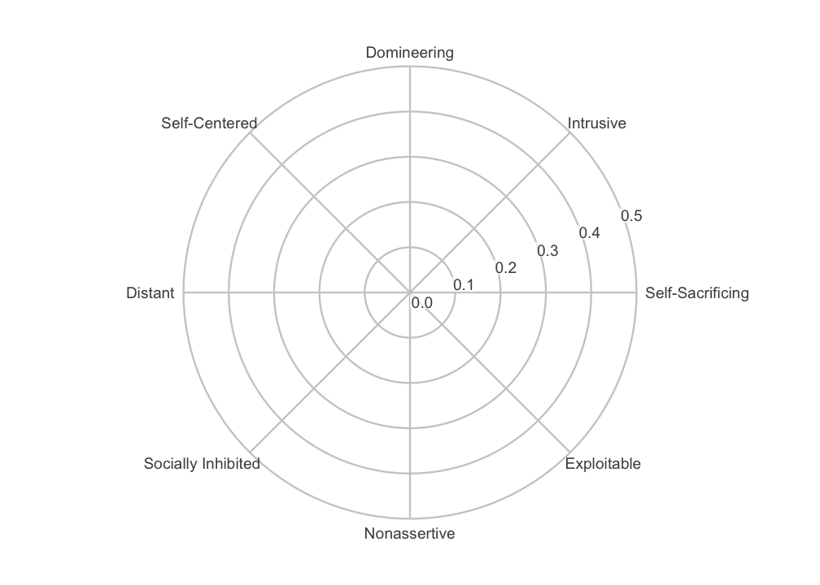

```r
ggcircumplex(octants(), labels = csip$Scales$Label)
```

If you are working with one of the instruments bundled with the package, you can pass it directly with `ggcircumplex(instrument = csip)`, and its scale angles and abbreviations are taken from the instrument rather than typed by hand.

Throughout, displacement runs counterclockwise from the right, and the 0/360 degree position is labeled 360.

## The coordinate system

`ggcircumplex()` is a convenience wrapper. Underneath it, the piece that makes a circumplex plot circular is `coord_circumplex()`, and you can add that to a bare `ggplot()` yourself when you want to build a figure from scratch. On top of the coordinate system you supply three things: an x-scale carrying the spoke breaks and labels, a data layer, and the theme.

```r
results <- ssm_analyze(
  jz2017,
  scales = PANO(),
  measures = c("NARPD", "ASPD")
)
subset(results$results, select = c(Label, a_est, d_est, a_lci, a_uci))
```

```
#>   Label    a_est    d_est     a_lci     a_uci
#> 1 NARPD 0.189244 108.9667 0.1537900 0.2271848
#> 2  ASPD 0.226159 115.9267 0.1905403 0.2640428
```

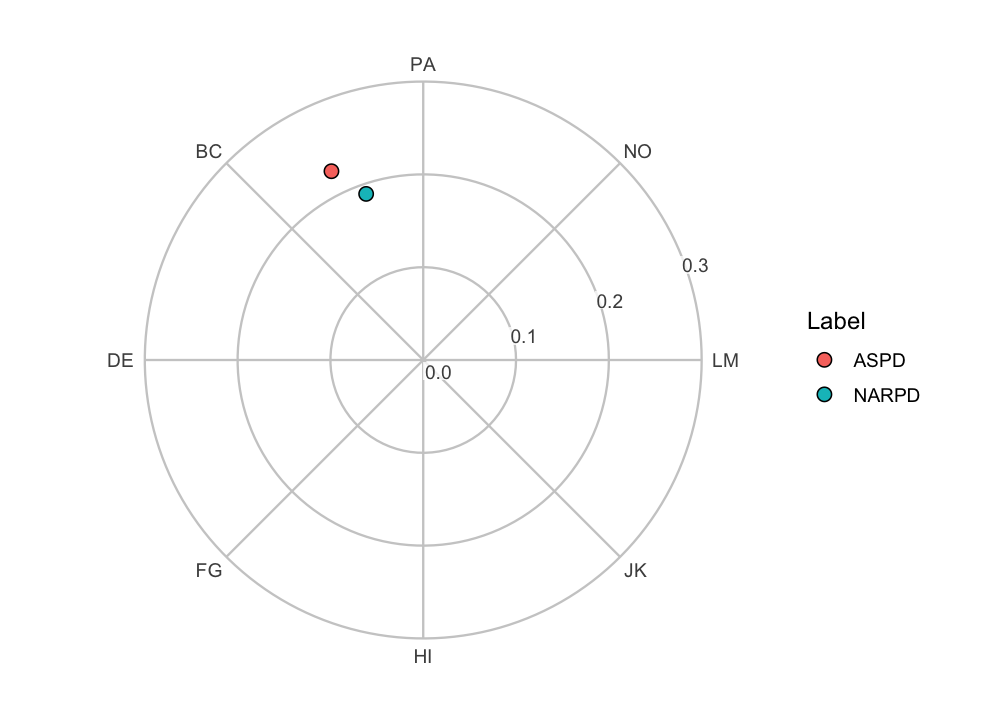

```r
ggplot(results$results) +
  coord_circumplex(amax = 0.3) +
  scale_x_continuous(breaks = octants(), labels = PANO()) +
  geom_ssm_point(aes(amplitude = a_est, displacement = d_est, fill = Label)) +
  theme_circumplex()
```

The `scale_x_continuous()` line is the one that tells the coordinate system where the scale angles are; without it the spokes would fall on `ggplot2`’s default breaks rather than on the octants. Supplying those breaks and labels, along with the theme, is what `ggcircumplex()` does on top of the coordinate system. Build from the parts when you want to vary one of those pieces; reach for `ggcircumplex()` when you do not.

Because the coordinate system owns the amplitude-to-radius mapping, `amax` is set exactly once per plot and the canvas and the data layers cannot disagree about what a given radius means. (Earlier versions of the package took an `amax` argument on each layer; those arguments are now deprecated and ignored, with a one-time note.) Leaving `amax = NULL` trains it from the data, as `ssm_plot_circle()` does.

### Moving the center

By default the center of the circle is amplitude 0, so radial distance is proportional to amplitude and the origin means “no differentiation among the scales.” The `center` argument moves that inner limit, which is useful when every profile sits in a narrow band of amplitudes and the interesting variation is squeezed against the rim:

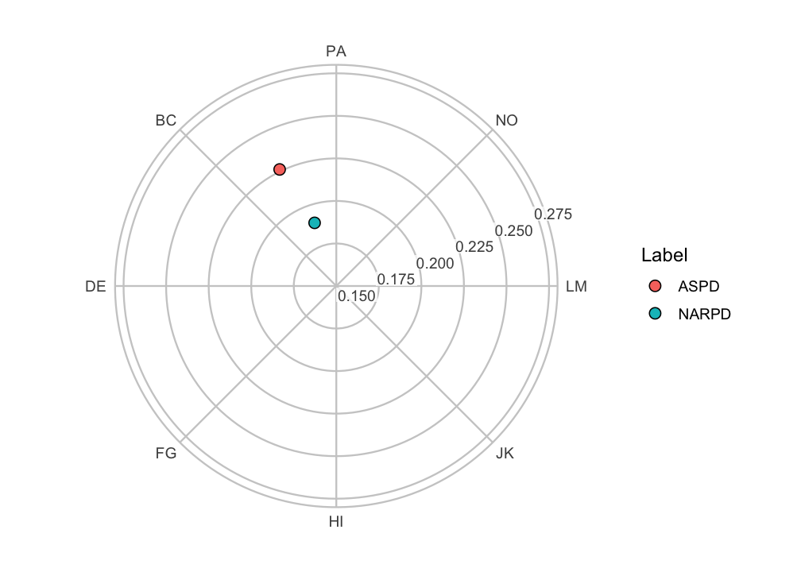

```r
ggplot(results$results) +
  coord_circumplex(amax = 0.28, center = 0.15) +
  scale_x_continuous(breaks = octants(), labels = PANO()) +
  geom_ssm_point(aes(amplitude = a_est, displacement = d_est, fill = Label)) +
  theme_circumplex()
```

This is a zoom, and it changes how the figure should be read. With a nonzero center, radial distance is no longer proportional to amplitude and the origin no longer represents zero amplitude, so differences in radius are exaggerated relative to the default view. The amplitude ring labels still report the true amplitudes, and they are what the reader should be directed to. Use a nonzero center to resolve closely spaced profiles, and say so in the caption.

### Moving the amplitude axis

The amplitude (radial) axis and its tick labels are placed automatically in the widest gap between the displacement spokes, so they never collide with a spoke label. You can override that with `r_axis_angle`, given as a displacement in degrees:

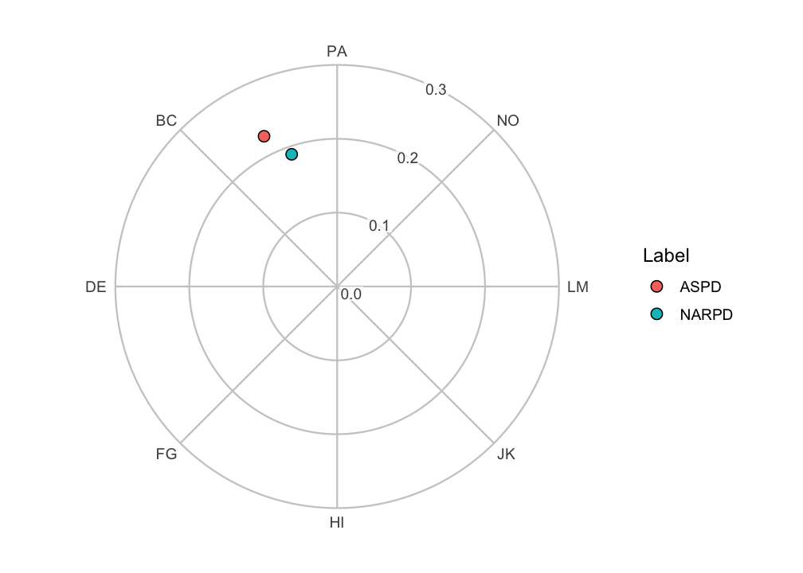

```r
ggplot(results$results) +
  coord_circumplex(amax = 0.3, r_axis_angle = 67.5) +
  scale_x_continuous(breaks = octants(), labels = PANO()) +
  geom_ssm_point(aes(amplitude = a_est, displacement = d_est, fill = Label)) +
  theme_circumplex()
```

Note that these examples build the canvas from its parts — the coordinate system, an x-scale carrying the spoke breaks and labels, and the theme — rather than adding a second coordinate system on top of `ggcircumplex()`, which `ggplot2` would replace with a message.

## Placing SSM results in the circle

Let’s draw the two-measure profile from above on a labeled canvas ourselves, rather than calling `ssm_plot_circle()`.

`geom_ssm_point()` places a point for each profile at its amplitude (`a_est`) and displacement (`d_est`), and `geom_ssm_arc()` draws the wedge spanning each profile’s amplitude confidence interval radially and its displacement confidence interval angularly. Both take the SSM parameters directly as aesthetics and handle the conversion into circular coordinates internally, including wrap-around when a displacement interval crosses the 0/360 degree boundary.

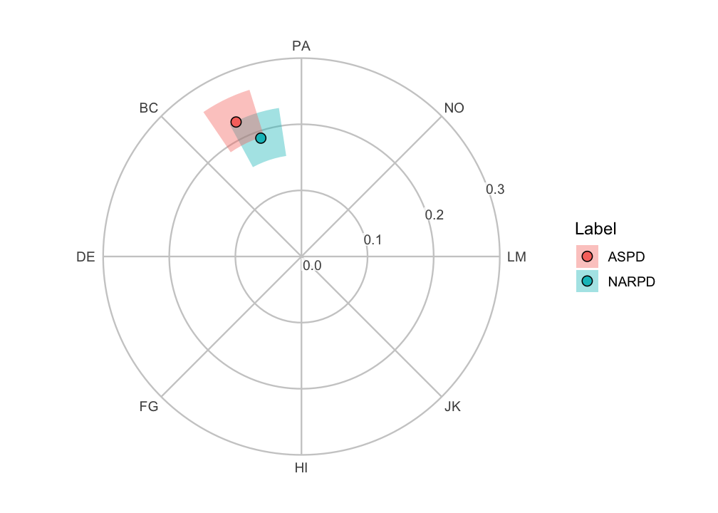

```r
ggcircumplex(octants(), labels = PANO(), amax = 0.3) +
  geom_ssm_arc(
    data = results$results,
    mapping = aes(
      amplitude_min = a_lci, amplitude_max = a_uci,
      displacement_min = d_lci, displacement_max = d_uci,
      fill = Label
    ),
    alpha = 0.4, color = NA
  ) +
  geom_ssm_point(
    data = results$results,
    mapping = aes(amplitude = a_est, displacement = d_est, fill = Label)
  )
```

Each arc displays two separate confidence intervals for one profile at once: its radial extent is the amplitude interval and its angular extent is the displacement interval. It is a convenient way to show both intervals together, not a single joint confidence region with its own coverage level, and not a hypothesis test. The angular extent in particular is a range of plausible *directions*: because zero degrees is an arbitrary reference direction rather than a null value, it should not be read as a significance test the way a confidence interval for a linear parameter (such as elevation) can be. Displacement is only worth interpreting at all when the amplitude interval is clearly above zero and the model fits reasonably well (see the “Introduction to SSM Analysis” vignette and `?ssm_analyze`).

## Restyling the canvas

`theme_circumplex()` is the theme `ggcircumplex()` applies. Because the rings, spokes, and labels are themed panel furniture rather than drawn geometry, any further theming reaches them. Adjust the base font size through the theme, and restyle the gridlines with an ordinary `theme()` call:

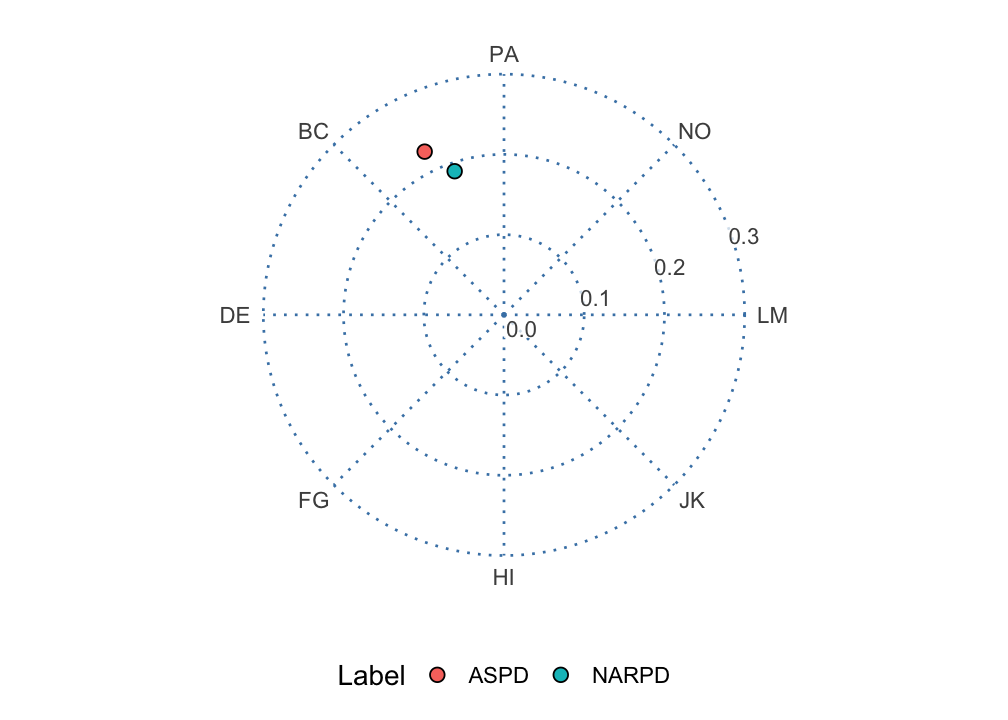

```r
ggcircumplex(octants(), labels = PANO(), amax = 0.3) +
  geom_ssm_point(
    data = results$results,
    mapping = aes(amplitude = a_est, displacement = d_est, fill = Label)
  ) +
  theme_circumplex(base_size = 14) +
  theme(
    panel.grid.major = element_line(color = "steelblue", linetype = "dotted"),
    legend.position = "bottom"
  )
```

## Composing custom layers

Because the canvas and geoms are ordinary `ggplot2` objects, you can add anything else to them. A common request is to show where individual respondents fall relative to a summary. We can compute each person’s own amplitude and displacement with `ssm_score()` and draw them as a faint cloud behind a group-level point.

```r
# Per-person SSM parameters for a subset of the sample. A respondent whose
# scores are flat has no displacement and is returned as NA (with a warning),
# so we keep only the well-defined profiles.
people <- ssm_score(
  jz2017[1:100, ],
  scales = PANO(),
  append = FALSE
)
people <- subset(people, !is.na(Disp))

# Group-level profile for the same subset
group <- ssm_analyze(jz2017[1:100, ], scales = PANO())

# The group amplitude is shorter than a typical individual amplitude
c(group = group$results$a_est, median_individual = median(people$Ampl))
```

```
#>             group median_individual
#>         0.3651863         0.5189425
```

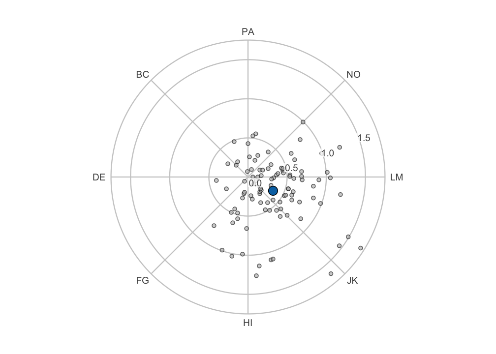

```r
ggcircumplex(octants(), labels = PANO(), amax = 1.75) +
  geom_ssm_point(
    data = people,
    mapping = aes(amplitude = Ampl, displacement = Disp),
    fill = "grey70", size = 1.5, alpha = 0.6
  ) +
  geom_ssm_point(
    data = group$results,
    mapping = aes(amplitude = a_est, displacement = d_est),
    fill = "#0072B2", size = 4
  )
```

The individual points spread widely around the circle while the group summary sits close to the origin, a picture that none of the built-in functions produce directly. That contrast is not an artifact: the group profile is the SSM of the *mean* scale scores, so its position is the average of the individual positions in (x, y) — and averaging vectors that point in different directions yields a resultant shorter than the typical individual vector, as the two amplitudes printed above show. A group amplitude smaller than a typical person’s therefore indicates disagreement about *direction* among the respondents, not that each person’s profile is flat. Any other `ggplot2` layer — text annotations, additional geoms, faceting — can be added the same way.

## Trajectories across occasions

When the same people are measured on the same scales at two or more occasions, `ssm_analyze_long()` (for long data) or `ssm_analyze(occasions = )` (for wide data) estimates one SSM profile per occasion, resampling persons so that within-person dependence across occasions is respected. `ssm_plot_trajectory()` then draws each SSM parameter against time.

Here is a small simulated three-wave data set, `long`, whose group profile rotates counterclockwise across the 0/360 degree boundary — the case worth seeing drawn. (The code that simulates it is omitted; it is not the point here. The data frame has one row per person per wave, the eight `PANO()` scale columns, an `id`, and a `wave` label.) We estimate one profile per wave with `ssm_analyze_long()`:

```r
results_long <- ssm_analyze_long(
  long,
  scales = PANO(),
  id = "id",
  occasion = "wave"
)
subset(results_long$results, select = c(Occasion, a_est, d_est, d_lci, d_uci))
```

```
#>   Occasion     a_est     d_est     d_lci     d_uci
#> 1       T1 0.6133765 332.44652 329.70848 335.43024
#> 2       T2 0.5879017 355.92454 352.64902 359.30751
#> 3       T3 0.5907495  17.84307  14.57562  21.11586
```

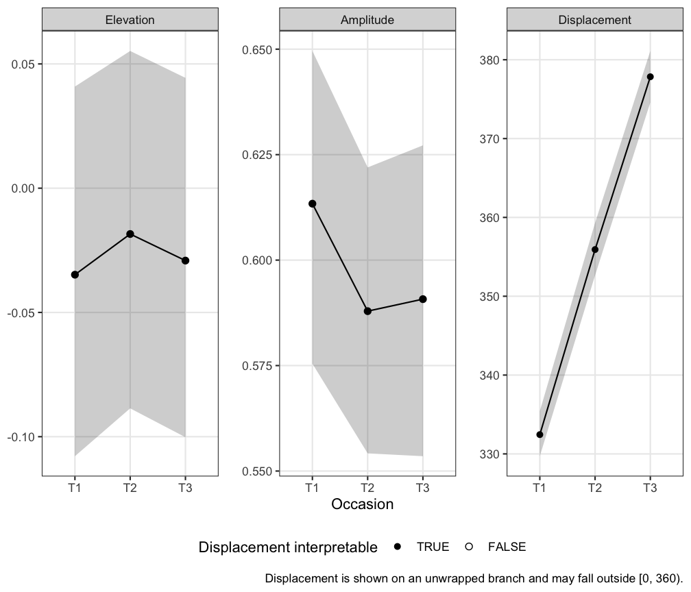

```r
ssm_plot_trajectory(results_long, drop_xy = TRUE)
```

Two things about the displacement panel are worth reading carefully. First, it is drawn on an *unwrapped* branch: the profile crosses the 0/360 boundary between the second and third wave, and rather than jumping a full turn the panel continues past 360, so values outside [0, 360) are expected there. Second, the occasion order comes from the data rather than from the plot: for a character occasion column it is first-appearance order, and for a factor it is the factor’s level order. Note that `factor()` sorts its levels alphabetically by default, which would place `T10` before `T2` — so if your occasion column is a factor, set its levels in temporal order.

The unwrap carries an assumption that no data can check: that the profile rotates less than a half-turn between consecutive occasions. Waves that are far apart in time, or a series with a gap, could rotate further than that and would be drawn as the shorter rotation regardless, so read widely spaced occasions with that in mind.

A time point whose amplitude interval is too close to zero for its displacement to be interpretable is drawn as a hollow point — a marker of an interpretability precondition, not a significance test. `drop_xy = TRUE` above omits the X-value and Y-value panels, leaving elevation, amplitude, and displacement.

The bands are the per-occasion confidence intervals, one per time point. They are not a simultaneous confidence band for the trajectory as a whole, and overlap (or its absence) between two occasions’ bands is not a test of change between them; for that, estimate the contrast directly (see `?ssm_analyze` and `ssm_plot_contrast()`).

`ssm_plot_trajectory()` also accepts a trajectory table — a data frame of `a_est`/`a_lci`/`a_uci` and `d_est`/`d_lci`/`d_uci` triples at numeric time points — which is how you plot a *model-based* trajectory evaluated from a fitted growth model rather than one estimated separately at each wave. That workflow is the subject of the “Growth Models on SSM Parameters” vignette.

### The same change as movement on the circle

The panels above show each parameter against time separately, which is the right figure for reading a confidence interval but a poor one for seeing *motion*: the amplitude and displacement of a single occasion are split across two panels. `geom_ssm_path()` draws the same series as a path on the circular canvas, so a change in (amplitude, displacement) reads as movement through circumplex space.

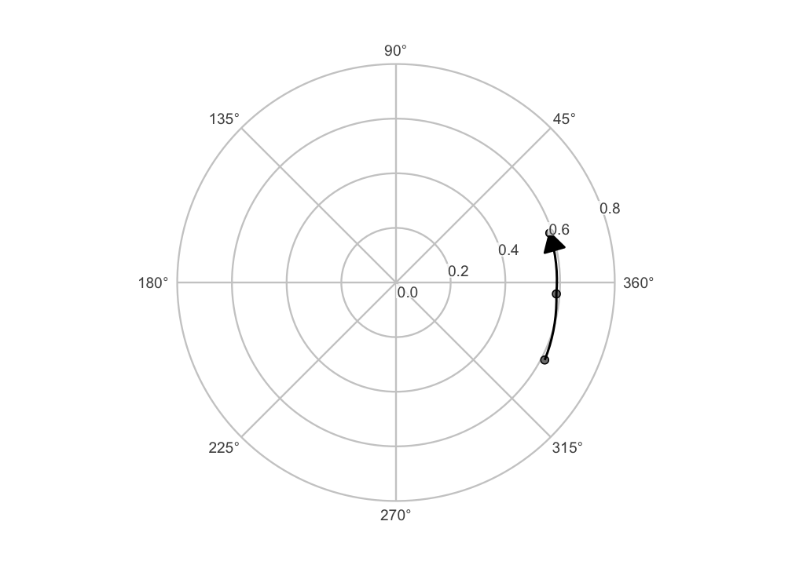

```r
ggcircumplex(octants(), amax = 0.8) +
  geom_ssm_point(
    data = results_long$results,
    mapping = aes(amplitude = a_est, displacement = d_est),
    size = 2
  ) +
  # Drawn after the points so the terminal arrowhead is not covered by the
  # final occasion's marker, and sized to clear it
  geom_ssm_path(
    data = results_long$results,
    mapping = aes(amplitude = a_est, displacement = d_est),
    arrow = arrow(length = unit(0.18, "inches"), type = "closed"),
    linewidth = 0.7
  )
```

The arrowhead marks the direction of time. Note what the layer does at the boundary: this profile moves from 330 to 355 to 20 degrees, and the step from the second to the third wave is drawn as the short 25 degree arc across the 0/360 pole rather than a 335 degree sweep the long way round. The path is curved because `coord_circumplex()` munches each segment along the polar geodesic — the layer supplies the ordering, not the drawing.

Occasions are connected in the order the rows appear in the data, exactly as `geom_path()` does, and mapping `group` draws one path per series. When you assemble a data frame by hand, sort it into time order first — for the reason noted above, sorting occasion labels as text puts `T10` before `T2` and silently reverses time. The wrapper below does that sorting for you.

The same figure is available ready-made from `ssm_plot_circle()`, which adds the path to its usual points and confidence wedges:

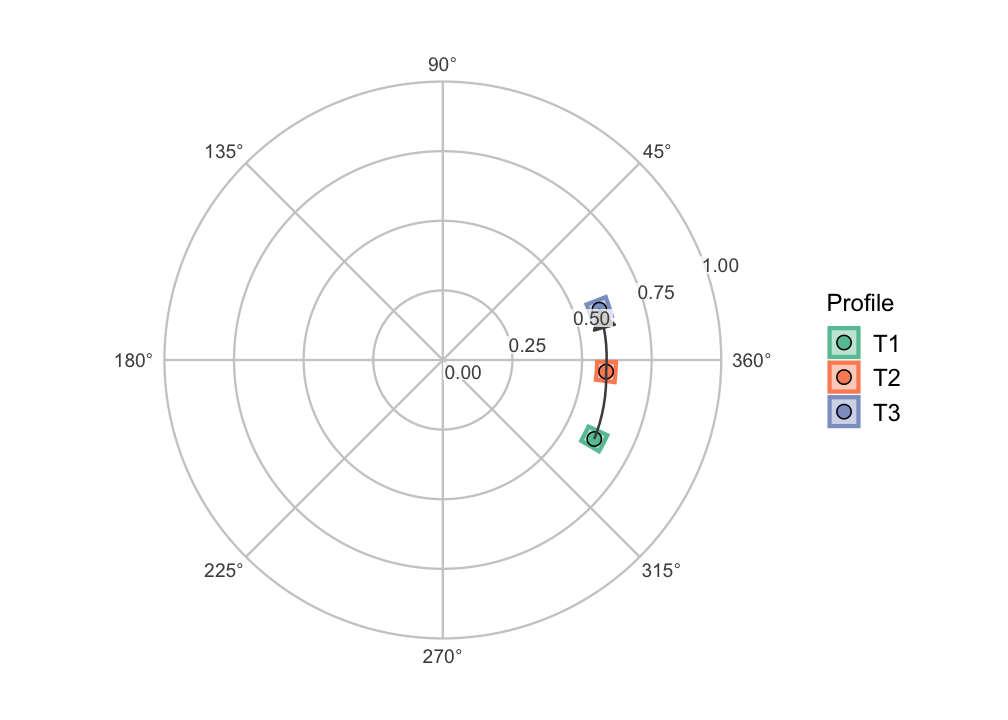

```r
ssm_plot_circle(results_long, path = TRUE)
```

An occasion whose displacement is undefined — a flat or zero-amplitude profile — *breaks* the path rather than being interpolated through, and the segment after the gap is still drawn on the correct branch. A path that skipped such an occasion would draw a movement that never happened.

## The angle axis for linear plots

Not every circumplex figure is circular. The score-by-angle curve drawn by `ssm_plot_curve()` is a linear plot whose x-axis runs through the scale angles. `scale_x_circumplex()` labels that axis consistently with the circular canvas: by default with the angle in degrees, or with custom labels or an instrument’s abbreviations.

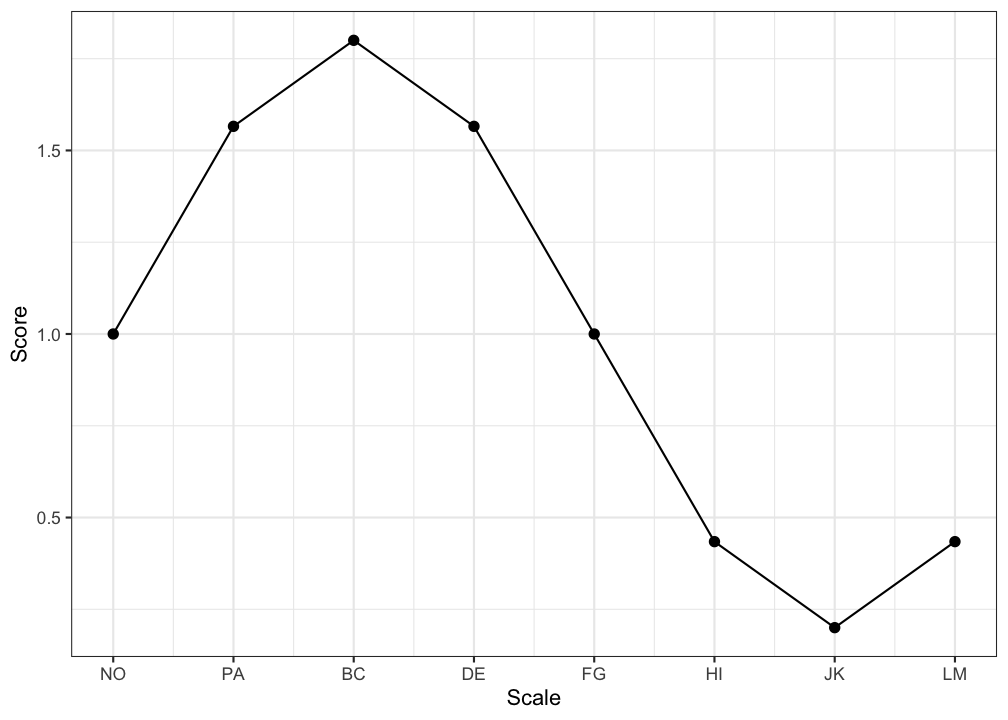

```r
angles <- octants()
curve <- data.frame(
  angle = angles,
  score = 1 + 0.8 * cos((angles - 135) * pi / 180)
)

ggplot(curve, aes(x = angle, y = score)) +
  geom_line() +
  geom_point(size = 2) +
  scale_x_circumplex(angles, labels = PANO()) +
  labs(x = "Scale", y = "Score") +
  theme_bw()
```

Passing the same `labels` (or the same `instrument`) to both `ggcircumplex()` and `scale_x_circumplex()` guarantees that a circular figure and a linear one label their scales identically.

## Relationship to the built-in plots

The built-in plotting functions are implemented on exactly these components: `ssm_plot_circle()` is `ggcircumplex()` plus `geom_ssm_arc()` and `geom_ssm_point()`, and `ssm_plot_curve()` uses `scale_x_circumplex()` for its angle axis. So you can always start from a built-in plot and add to it, or rebuild it from the pieces when you need finer control. Whichever route you take, the coordinates are computed the same way, so the results line up.

## References

- Gurtman, M. B. (1992). Construct validity of interpersonal personality measures: The interpersonal circumplex as a nomological net. *Journal of Personality and Social Psychology, 63*(1), 105–118.
- Wright, A. G. C., Pincus, A. L., Conroy, D. E., & Hilsenroth, M. J. (2009). Integrating methods to optimize circumplex description and comparison of groups. *Journal of Personality Assessment, 91*(4), 311–322.
- Zimmermann, J., & Wright, A. G. C. (2017). Beyond description in interpersonal construct validation: Methodological advances in the circumplex Structural Summary Approach. *Assessment, 24*(1), 3–23.